# Outlier Detection in a Linear Signal with MCMC

## Introduction :

In this notebook, we will simulate a linear model and then we will add some ouliers and try to detect them with the implementation of a Gibbs sampler.

## MCMC :

Also known as the Markov Chain Monte Carlo is the main family of algorithms that uses the bayesian approach for statistical approach. It allows us to infere the posterior distribution. this family contains various algorithms such as Metropolis Hasting , Gibbs Sampler and also Hamiltonian Monte Carlo. In our case we will explain both of Metropolis Hasting and Gibbs Sampler algorithms and use The Gibbs Sampler to detect Outliers in a linear signal that we will simulate .

## Why Do we use MCMC for Inference ? :

A statistician could say why do we use MCMC when we could just by using conjugate priors ( the posterior distributions $ \mathbb{p}(\theta | x ) $ are in the same probability family as the prior probability distribution $ \mathbb{p}(\theta)$ ) infere our posterior distributions . The answer to this question is that not all models can be defined by conjugate priors. There are may complicated models with numerous parameters (multi-dimensional) and the problem lies here : We can't with analytical method to infer posterior distributions , If this is the Bayes Rule :

$$ \mathbb{P}(\theta | D ) = \dfrac{\mathbb{P}(D | \theta ) \mathbb{P}(\theta)}{\mathbb{P}(D)} $$

Then We need to calculate $\mathbb{P}(D)$ , In order to do that , we need to evaluate this Integral : $$\int_{\theta} \mathbb{P}(D, \theta) d \theta $$

Due to the multi-dimensionality of the parameters we need to turn to a numerical approximation method instead and Monte Carlo seems to be the best candidate for the job.

The best thing about Monte Carlo Markov Chain is that they perform an intelligent search or scan the multi-dimensional space. As a matter of fact, the idea is to sample from the posterior distribution by combining Monte Carlo ( random search ) with the fact that those searches are memoryless (they don't depend on the initial state) which the basic idea of markov chains.

## MCMC algorithms :

### The Metropolis Hasting Algorithm :

#### Theory :

Metropolis-Hasting is a specific implementation of mcmc and it showed its performance with multi-dimentional data.

This algorithm requires a simple distribution function or a proposal distribution $\mathbb{Z}$ the point of this distribution is that M-H will used to randomly walk in the space and take values to accept them or reject them. this walk don't depend on the initial state ( The Markov Chain part of the algorithm).

The likelihood of each sample drawn is calculated with function that is proportional to the posterior that we want to take a sample from we'll call it $\mathbb{f}$ .

To get from a positon from a parameter $\theta$ to another we need just to propose a new parameter $\theta ' $ and draw a sample from the proposed disrtibution which is $ Q(\theta , \theta ') $ . And then to decide whether we accept this transition or not we need to compute this ratio : $$ \dfrac{\mathbb{P}(\theta '/ D ) }{ \mathbb{P}(\theta / D) } $$ Which is by usin the bayes formula :

$$ \dfrac{\mathbb{P}(D | \theta ' ) \mathbb{P}(\theta ')}{\mathbb{P}(D| \theta) \mathbb{P}(\theta )} $$

#### Algorithm :

1) Let $\theta^{(1)} $ be the initial sample from the distribution of $ (\theta) $

2) Sample $\theta ^* $ from $ Q(\theta , \theta ^*)$

3) Accept $ \theta ^*$ if : $$ \dfrac{ \mathbb{f}(D/ \Theta= \theta ') \mathbb{P}(\theta ')}{\mathbb{f}(D/ \Theta= \theta ) \mathbb{P}(\theta)} > r $$

With r = genetated a uniform random number in [0,1]

### Gibbs Sampler

#### Theory :

The idea in Gibbs sampling is to generate posterior samples by using other variables : We sample from each variable' conditional variable's disribution with the other variables we'll explain with more details in the outlier detection script.

#### Algorithm

1) Initialize $x^{(0)}$ ~ $q(x)$ # prior distribution

2) for i = [1,n] do

$x_1^{(i)}$ ~ $\mathbb{p}(X_1=x_1/ X_2^{i-1}=x_2,...,X_D^{i-1}=x_d)$

$x_2^{(i)}$ ~ $\mathbb{p}(X_2=x_2/ X_1^{i}=x_1,X_3^{i-1}=x_3...,X_D^{i-1}=x_d )$

```
 .

 .

 .
```

$ x_D^{(i)}$ ~ $\mathbb{p}(X_D=x_d/ X_1^{i}=x_1,X_2^{i}=x_2...,X_{D-1}^{i}=x_{d-1}) $

```
  end for
```

## Oulier Detction for a Linear data with MCMC

### Signal simulation :

```python
from IPython.display import Math
import numpy as np
                                    # Import Python modules
import random
```

```python
beta = 3                                            # Slope
alpha=13
x = np.arange(10,50,.5)             # generating the X column

x = x +  np.random.normal(size=x.size)  # adding some white noise

y = beta * x + alpha                 # the final data
```

Here , we obtained a linear signal with the formula : $$ Y= \alpha+ \beta X + \varepsilon $$

**Drawing the signal's scatter plot :**

```python
from matplotlib import pyplot as plt
```

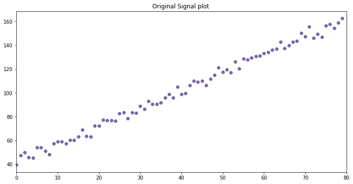

```python
plt.figure(figsize=(12, 6));
plt.scatter(range(len(y)), y, color="#7A68A6");
plt.title('Original Signal plot ');
plt.xlim([0, len(y)]);
```

Now , We add some **outliers** to our signal :

```python
y_with_outlier = np.copy(y)
g= np.arange(len(x)/5., len(x), len(x)/5.)
myList = [int(round(x)) for x in g]
                                                                   # Add some outliers
for i in myList:
    y_with_outlier[i]= 100*(random.random()+.5) + y[i]

y_with_outlier = np.asarray(y_with_outlier)                        # Convert it to an array
spread = np.asarray([1 for _ in range(y_with_outlier.size)])
```

**Drawing the modified signal's scatter plot :**

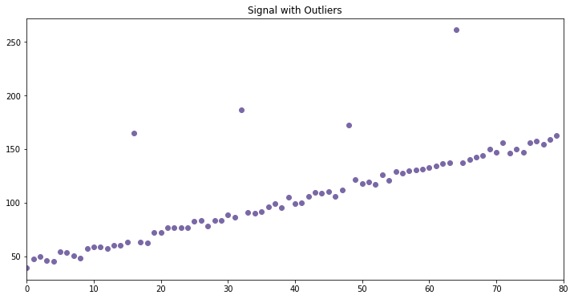

```python
plt.figure(figsize=(12, 6));
plt.scatter(range(y_with_outlier.size), y_with_outlier, color="#7A68A6");
plt.title('Signal with Outliers');
plt.xlim([0, len(y_with_outlier)]);
```

We could see here that the signal has some observation that we can consider as ouliers

### Applying the Gibbs sampler algorithm to detect outliers

#### The Pymc Library

PyMC is a python module that implements Bayesian statistical models and fitting algorithms, including Markov chain Monte Carlo. Its flexibility and extensibility make it applicable to a large suite of problems. Along with core sampling functionality, PyMC includes methods for summarizing output, plotting, goodness-of-fit and convergence diagnostics.

```python
import pymc
```

We begin by defining our priors

```python
outlier_points = pymc.Uniform('outlier_points', 0, 1.0, value=0.1)      # Ouliers
mean_outliers = pymc.Uniform('mean_outliers', -100, 100, value=0)       # Outlier's mean
spread_outliers = pymc.Uniform('spread_outliers', 0, 100, value=0.01)     # spread
prob_limit=pymc.Uniform('prob_limit',0,1.0,value=0.1)                    # threshold
```

Then , we write our regression model :

First of all , we choose the prior distribution for the slope , we'll use a modified Cauchy because it's an invariant distribution throught rotation of coordinates which is equivalent to a uniform density on the angle $\theta$ = arctan $\beta$ for more information please consult this article : https://projecteuclid.org/download/pdf_1/euclid.ba/1339616542

Then We define our Model as the deterministic part of the model.

```python
@pymc.stochastic                                            # Decorated function in Python
def slope_and_intercept(value=[1., 5.]):
    slope, intercept = value
      # uniform prior = arctan(slope)
         # d[arctan(x)]/dx = 1 / (1 + x^2)
    prob = np.log(1. / (1. + slope ** 2))     #loglikelihood
    return prob

@pymc.deterministic
def model_(x=x, slope_and_intercept=slope_and_intercept):
    slope, intercept = slope_and_intercept
    fit = slope * x + intercept
    return fit
```

##### Outlier and Inliers distributions :

we will reason on the inlier points , As a manner of fact , an inlier is represented by a Bernoulli : $$ p_{inlier} \sim \operatorname{Bern} \left({ 1 - p_{outlier}}\right) $$

Also, We define our posterior likelihood of the ourtlier so that we can detect them by having a low posterior.

```python
inlier = pymc.Bernoulli('inlier', p=1 - outlier_points, value=np.zeros(x.size))
```

```python
def log_posterior_likelihood_of_outlier(y_with_outlier, mu, spread, inlier, mean_outliers, spread_outliers):
    inlier_posterior = np.sum(inlier * (np.log(2 * np.pi * spread ** 2) + (y_with_outlier - mu) ** 2 / (spread ** 2)))
    outlier_posterior = np.sum((1 - inlier) * (np.log(2 * np.pi * ((spread ** 2) + (spread_outliers ** 2))) + (y_with_outlier - mean_outliers) ** 2 / ((spread ** 2) + (spread_outliers ** 2))))
    return -0.5 * (inlier_posterior + outlier_posterior)
```

Then, we implement all of our models and variables into one model to estimate the parameters

```python
outlier_distribution = pymc.stochastic_from_dist('outlier_distribution',
                                              logp=log_posterior_likelihood_of_outlier,
                                              dtype=np.float,
                                              mv=True)
```

```python
outlier_dist = outlier_distribution('outlier_dist',
                          mu=model_,
                          spread=spread,
                          mean_outliers=mean_outliers,
                          spread_outliers=spread_outliers,
                          inlier=inlier,
                          observed=True,
                          value=y_with_outlier)
```

```python
model = dict(outlier_dist=outlier_dist,
             slope_and_intercept=slope_and_intercept,
             model_=model_,
             inlier=inlier,
             outlier_points=outlier_points,
             mean_outliers=mean_outliers,
             spread_outliers=spread_outliers,
             prob_limit=prob_limit,

            )
```

And We generate our samples , with 100000 Chain with avoiding the first 20000 chains.

```python
mcmc = pymc.MCMC(model)
mcmc.sample(100000, burn= 20000)

slope_and_intercept_trace = mcmc.trace('slope_and_intercept')[:].astype(float)
model_trace = mcmc.trace('model_')[:].astype(float)
outlier_points_trace = mcmc.trace('outlier_points')[:].astype(float)
spread_outliers_trace = mcmc.trace('spread_outliers')[:]
prob_limit=mcmc.trace('prob_limit')[:]
```

```
 [-----------------100%-----------------] 100000 of 100000 complete in 85.2 sec
```

```python
probability_of_points = mcmc.trace('inlier')[:].astype(float).mean(0)
outlier_x = x[probability_of_points <mcmc.trace('prob_limit')[:].astype(float).mean()]
outlier_y = y_with_outlier[probability_of_points < mcmc.trace('prob_limit')[:].astype(float).mean()]
```

#### Plotting the Results ans Interpretation :

```python
import seaborn as sns
```

```
No handles with labels found to put in legend.
```

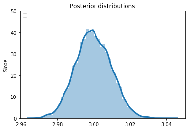

```python
sns.distplot(slope_and_intercept_trace[:,0], hist = True, kde = True,
                 kde_kws = {'linewidth': 3}
                 )
plt.legend(loc="upper left");
plt.title("Posterior distributions");
plt.ylim([0, 50]);
plt.ylabel("Slope");
```

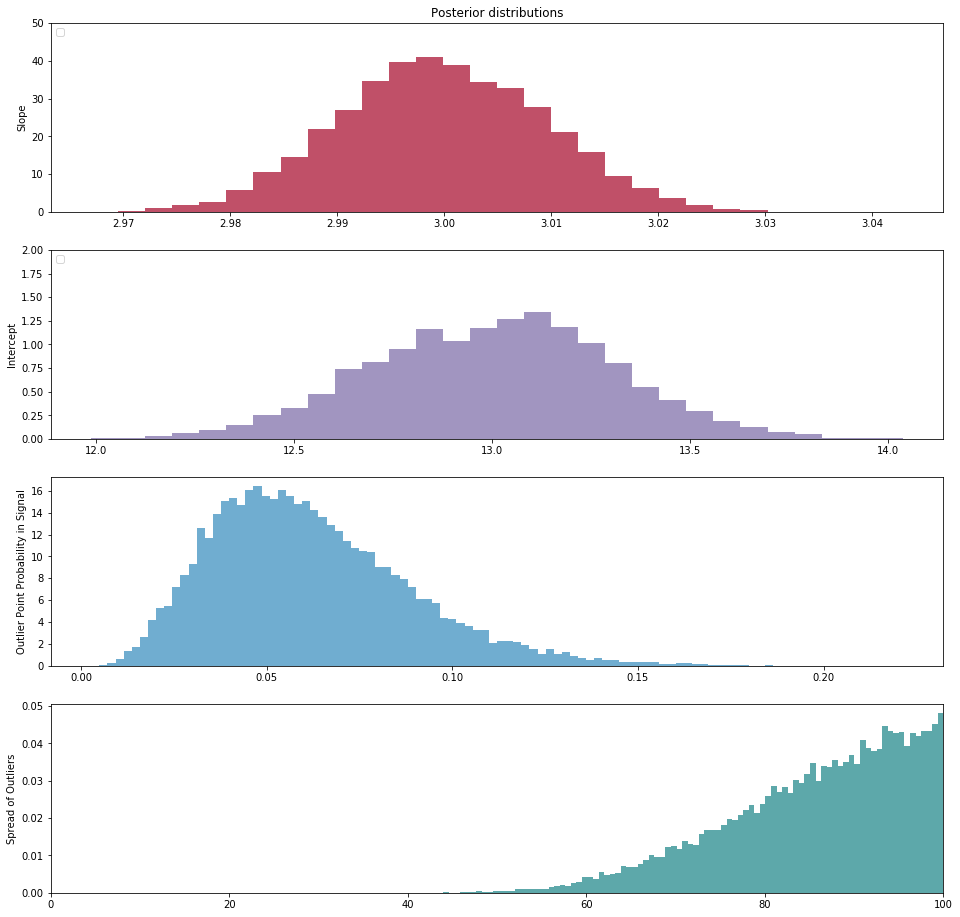

```python
fix, ax = plt.subplots(figsize=(16,16))

ax = plt.subplot(411)
plt.hist(slope_and_intercept_trace[:,0], histtype='stepfilled', bins=30, alpha=.7,
                                        color="#A60628", normed=True);
plt.legend(loc="upper left");
plt.title("Posterior distributions");
plt.ylim([0, 50]);
plt.ylabel("Slope");

ax = plt.subplot(412);
plt.hist(slope_and_intercept_trace[:,1], histtype='stepfilled', bins=30,
         alpha=.7, color="#7A68A6", normed=True);
plt.legend(loc="upper left");
plt.ylim([0, 2]);
plt.ylabel("Intercept");

plt.subplot(413);
plt.hist(outlier_points_trace, histtype='stepfilled', bins=100, alpha=.7,
         color="#348ABD",  normed=True);
plt.ylabel("Outlier Point Probability in Signal");

plt.subplot(414);
plt.hist(spread_outliers_trace, histtype='stepfilled', bins=100, alpha=.7,
         color="#188487",  normed=True);
plt.ylabel("Spread of Outliers");
plt.xlim([0, np.max(spread_outliers_trace)]);
```

```python
round(slope_and_intercept_trace[:,0].mean())
```

```
3.0
```

```python
round(slope_and_intercept_trace[:,1].mean())
```

```
13.0
```

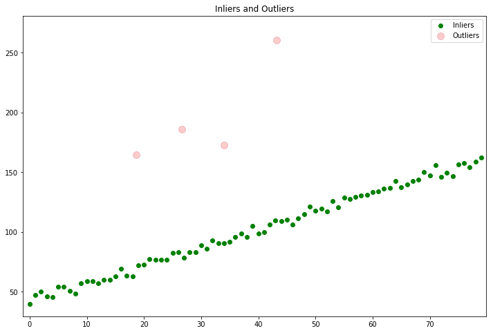

```python
fig, ax = plt.subplots(figsize=(12, 8))
ax.scatter(range(len(y)), y, color="g" , label = 'Inliers');
ax.scatter(outlier_x, outlier_y,  facecolors='r', edgecolors='#A60628', label='Outliers', lw=1, s=100, alpha=0.2)

ax.set_xlim(np.min(x)-10, np.max(x) + 30);
ax.set_ylim(np.min(y_with_outlier)-10, np.max(y_with_outlier) + 20);
ax.set_title('Inliers and Outliers');
plt.legend();
```

Here are our detected Outliers :

```python
import pandas as pd
pd.DataFrame(outlier_y,outlier_x)
```

|  | 0 |
| --- | --- |
| 18.658937 | 164.600134 |
| 26.659471 | 186.271847 |
| 33.993479 | 172.481082 |
| 43.213911 | 260.810138 |